# Médicos por Especialidad

Alicia Perdices Guerra

3 de mayo, 2021

#### **1.PROCESAMIENTO DE LOS DATOS.**

- En primer lugar leemos el fichero:

```r
medicos_e<-read.csv("C:/temp/Medicos_x_especialidad.csv",sep= ",")
```

- Realicemos una breve inspección de los datos

```r
str(medicos_e)
```

```
## 'data.frame':    1800 obs. of  6 variables:
##  $ TIME              : int  2010 2010 2010 2010 2010 2010 2010 2010 2010 2010 ...
##  $ GEO               : Factor w/ 36 levels "Albania","Austria",..: 3 3 3 3 3 4 4 4 4 4 ...
##  $ UNIT              : Factor w/ 1 level "Number": 1 1 1 1 1 1 1 1 1 1 ...
##  $ MED_SPEC          : Factor w/ 5 levels "General paediatricians",..: 3 2 4 5 1 3 2 4 5 1 ...
##  $ Value             : Factor w/ 1139 levels ":","0.00","1 001.00",..: 210 210 2 354 66 806 723 532 483 91 ...
##  $ Flag.and.Footnotes: Factor w/ 8 levels "","b","bd","be",..: 1 1 1 1 1 1 1 1 1 1 ...
```

```r
colnames(medicos_e) #Nombre de las variables
```

```
## [1] "TIME"               "GEO"                "UNIT"
## [4] "MED_SPEC"           "Value"              "Flag.and.Footnotes"
```

```r
nrow(medicos_e) #Número de registros
```

```
## [1] 1800
```

```r
ncol(medicos_e) #Número de variables
```

```
## [1] 6
```

*Observamos las siguientes variables:

- **TIME**: variable cuantitativa. Indica el año en el que se ha realizado la medida, en este caso el valor de la variable “Value”. Se ha cargado bien como número entero.
- **GEO**: variable cualitativa. Indica el país o región en el que se ha realizado la medida.Se ha cargado bien como factor.
- **UNIT**: variable cualitativa. Indica la medida de la variable valor.Se ha cargado bien como factor.
- **MED_SPEC**: variable cualitativa. Indica la especialidad médica.
- **Value**: Variable cuantitativa. Indica el número de médicos por especialidad médica y por países.
- **Fal.and.footnotes**. Notas sobre etiquetas. Eliminamos esta columna.

*Años de las mediciones:

```r
unique(medicos_e$TIME)
```

```
##  [1] 2010 2011 2012 2013 2014 2015 2016 2017 2018 2019
```

*Paises:

```r
unique(medicos_e$GEO)
```

```
##  [1] Belgium
##  [2] Bulgaria
##  [3] Czechia
##  [4] Denmark
##  [5] Germany (until 1990 former territory of the FRG)
##  [6] Estonia
##  [7] Ireland
##  [8] Greece
##  [9] Spain
## [10] France
## [11] Croatia
## [12] Italy
## [13] Cyprus
## [14] Latvia
## [15] Lithuania
```

[output cut: 22 more lines]

*Unidad de las mediciones:

```r
unique(medicos_e$UNIT)
```

```
## [1] Number
## Levels: Number
```

*Variable que indica la especialidad médica

```r
unique(medicos_e$MED_SPEC)
```

```
## [1] Generalist medical practitioners
## [2] General practitioners
## [3] Other generalist medical practitioners
## [4] Specialist medical practitioners
## [5] General paediatricians
## 5 Levels: General paediatricians ... Specialist medical practitioners
```

- Eliminamos la columna Fal.and.footnotes.

```r
medicos_e<-medicos_e[,-6]
```

- Tendríamos que convertir la columna Value a numérico porque se ha cargado como factor y es erróneo. El resto de variables tienen el tipo correcto.

```r
medicos_e$Value<-as.character(medicos_e$Value)
medicos_e$Value<-(gsub(',','.',medicos_e$Value) )
medicos_e$Value<-(gsub(' ','',medicos_e$Value) )
medicos_e$Value<-as.numeric(medicos_e$Value)
```

- Comprobamos que valores tenemos en la columna **Value**:

```r
table(medicos_e$Value, useNA = "ifany")
```

```
##
##       0       5       6      10      11      12      13      14      15      16
##      71       9       1       2       3       1       1       2       5       1
##      18      19      20      21      23      24      25      26      27      34
##       1       1       1       1       2       3       2       2       2       1
##      35      37      44      46      48      55      59      63      67      68
##       1       5       1       1       1       1       2       1       1       1
##      74      76      79      81      82      83      84      85      87      90
##       2       1       1       2       1       3       2       2       2       1
##      91      92      96      98     101     102     104     106     117     119
##       2       2       1       1       1       1       1       1       1       1
##     120     122     123     130     132     133     145     146     147     154
##       1       2       1       1       1       1       1       1       1       1
##     157     161     163     165     166     167     168     169     172     173
##       2       1       4       1       1       1       2       2       3       2
```

[output cut: 214 more lines]

- Observamos que tenemos **390 valores perdidos**.Guardamos en la variable **idx** los índices de los registros con valores **NA** de la variable **Value**.

```r
idx<-which(is.na(medicos_e$Value))
length(idx)
```

```
## [1] 390
```

- Grafiquemos la información que contiene la variable **Value**

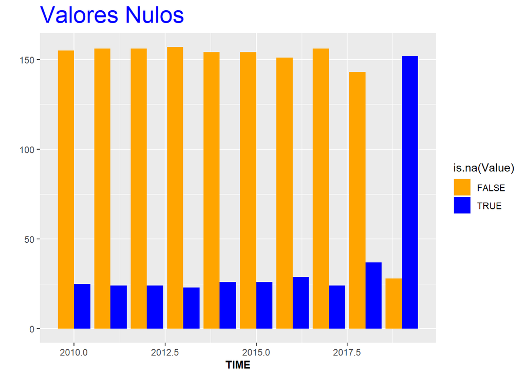

```r
library(ggplot2)
library(scales)
g = ggplot(medicos_e, aes(TIME, fill=is.na(Value)) ) +
labs(title = "Valores Nulos")+ylab("") +
theme(plot.title = element_text(size = rel(2), colour = "blue"))

g+geom_bar(position="dodge") + scale_fill_manual(values = alpha(c("orange", "blue"), 1)) +
theme(axis.title.x = element_text(face="bold", size=10))
```

- En caso de detectar algún valor anómalo (en nuestro caso los NAS) en las variables tendríamos que realizar una imputación de esos valores o bien sustituyéndolos por la media o usando el algoritmo KNN ( k-Nearest Neighbour) con los 3 vecinos más cercanos usando la distancia que consideremos, en este caso usaremos Gower(Mediana), por ser una medida más robusa frente a extremos.

```r
library(VIM)
output<-kNN(medicos_e, variable=c("Value"),k=3)
medicos_e<-output
```

- Comprobamos que no tenemos valores nulos después de la imputación

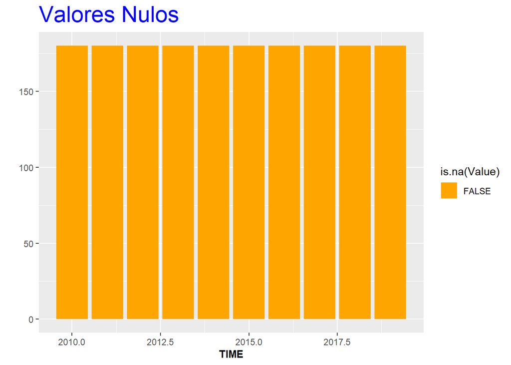

```r
g = ggplot(medicos_e, aes(TIME, fill=is.na(Value)) ) +
labs(title = "Valores Nulos")+ylab("") +
theme(plot.title = element_text(size = rel(2), colour = "blue"))

g+geom_bar(position="dodge") + scale_fill_manual(values = alpha(c("orange", "blue"), 1)) +
theme(axis.title.x = element_text(face="bold", size=10))
```

- Con el siguiente gráfico, observaremos que la variable **Value** tiene outliers o valores extremos

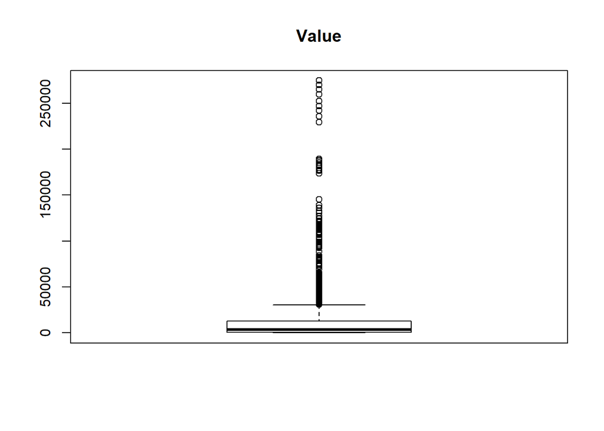

```r
boxplot(medicos_e$Value, main="Value")
```

- Por otro lado, revisamos para el resto de columnas si tenemos valores NA.(desconocidos o perdidos)

```r
table(medicos_e$TIME, useNA = "ifany")
```

```
##
## 2010 2011 2012 2013 2014 2015 2016 2017 2018 2019
##  180  180  180  180  180  180  180  180  180  180
```

```r
table(medicos_e$GEO, useNA = "ifany")
```

```
##
##                                          Albania
##                                               50
##                                          Austria
##                                               50
##                                          Belgium
##                                               50
##                                         Bulgaria
##                                               50
##                                          Croatia
##                                               50
##                                           Cyprus
##                                               50
##                                          Czechia
##                                               50
##                                          Denmark
##                                               50
##                                          Estonia
##                                               50
##                                          Finland
##                                               50
##                                           France
##                                               50
## Germany (until 1990 former territory of the FRG)
##                                               50
##                                           Greece
##                                               50
##                                          Hungary
##                                               50
##                                          Iceland
##                                               50
##                                          Ireland
##                                               50
##                                            Italy
##                                               50
##                                           Latvia
##                                               50
##                                    Liechtenstein
##                                               50
##                                        Lithuania
```

[output cut: 18 more lines]

```
##                                               50
##                                           Serbia
##                                               50
##                                         Slovenia
##                                               50
##                                            Spain
##                                               50
##                                           Sweden
##                                               50
##                                      Switzerland
##                                               50
##                                           Turkey
##                                               50
##                                   United Kingdom
##                                               50
```

```r
table(medicos_e$UNIT, useNA = "ifany")
```

```
##
## Number
##   1800
```

```r
table(medicos_e$MED_SPEC, useNA = "ifany")
```

```
##
##                 General paediatricians                  General practitioners
##                                    360                                    360
##       Generalist medical practitioners Other generalist medical practitioners
##                                    360                                    360
##       Specialist medical practitioners
##                                    360
```

Observamos que no existen ahora valores perdidos después de la imputación.La suma de las cantidades de cada variable, suman el total.

- Finalmente, creamos un fichero con toda la información corregida.

```r
write.csv(medicos_e, file="Medicos_x_especialidad_clean.csv", row.names = FALSE)
```